# Milestone Report

Marcos Antonio Ribeiro

March 22, 2016.

### Overview

The goal of this report is an exploratory analysis of some text documents in order to build a prediction model to be used in predicting the next word to be typed, so the user will get some help in typing when using mobile devices.

### About the exploration

We are going to use the dfm function from quanteda package to clean our data and create the document feature matrix.

```
Our cleaning process consists of:
1 transforming the data to lowercase;
2 remove numbers, punctuation, separators.
```

As we intend to predict typing, we will not remove stop words and will not stem words. Also, profanity words will not be removed in order to not decrease the prediction accuracy, I´d rather filter them after prediction. In this case, it´s important to keep all the words in a prediction model to get a better accuracy. It’s common to use some foreign expression, so also, we won´t remove them.

### Files to be explored:

```
1 en_US.blogs.txt
2 en_US.news.txt
3 en_US.twitter.txt
```

### Loading libraries and setting up working directory

```r
    library(tm)
    library(wordcloud)
    library(quanteda)
    setwd("C:/Coursera/Git/courses/Capstone")
```

### Exploring en_US.blogs.txt

```r
    # Reading the file
    con_blogs <- file("final/en_US/en_US.blogs.txt", "r")
    blogs <- corpus(readLines(con = con_blogs, encoding='UTF-8'))
```

### The maximum number of lines in a blog

```r
    max(nsentence(blogs))
```

```
## [1] 323
```

```r
    max(ntoken(blogs))
```

```
## [1] 7573
```

### Creating the document feature matrix with 1 ngram

```r
    dfm_blogs <- dfm(blogs
           , verbose = TRUE
           , toLower = TRUE
           , removeNumbers = TRUE
           , removePunct = TRUE
           , removeSeparators = TRUE
           , removeTwitter = FALSE
           , stem = FALSE
           , ignoredFeatures = NULL
           , keptFeatures = NULL
           , language = ""
           , thesaurus = NULL
           , dictionary = NULL
           , valuetype = c("glob"))
```

```
## Creating a dfm from a corpus ...
##    ... lowercasing
##    ... tokenizing
##    ... indexing documents: 899,288 documents
##    ... indexing features: 380,897 feature types
##    ... created a 899288 x 380897 sparse dfm
##    ... complete.
## Elapsed time: 198.06 seconds.
```

```r
    head(dfm_blogs)
```

```
## Document-feature matrix of: 899,288 documents, 380,897 features.
## (showing first 6 documents and first 6 features)
##        features
## docs    in the years thereafter most of
##   text1  1   2     1          1    1  1
##   text2  0   0     0          0    0  0
##   text3  1   6     0          0    0  2
##   text4  1   1     0          0    0  0
##   text5  3   5     0          0    0  0
##   text6  0   0     0          0    0  0
```

### Creating the document feature matrix with 2 ngrams

```r
    dfm_blogs2 <- dfm(blogs
           , verbose = TRUE
           , toLower = TRUE
           , removeNumbers = TRUE
           , removePunct = TRUE
           , removeSeparators = TRUE
           , removeTwitter = FALSE
           , stem = FALSE
           , ignoredFeatures = NULL
           , keptFeatures = NULL
           , language = ""
           , thesaurus = NULL
           , dictionary = NULL
           , valuetype = c("glob"), ngrams=2)
```

```
## Creating a dfm from a corpus ...
##    ... lowercasing
##    ... tokenizing
##    ... indexing documents: 899,288 documents
##    ... indexing features: 6,340,801 feature types
##    ... created a 899288 x 6340801 sparse dfm
##    ... complete.
## Elapsed time: 270.38 seconds.
```

```r
    head(dfm_blogs2)
```

```
## Document-feature matrix of: 899,288 documents, 6,340,801 features.
## (showing first 6 documents and first 6 features)
##        features
## docs    in_the the_years years_thereafter thereafter_most most_of of_the
##   text1      1         1                1               1       1      1
##   text2      0         0                0               0       0      0
##   text3      0         0                0               0       0      0
##   text4      0         0                0               0       0      0
##   text5      0         0                0               0       0      0
##   text6      0         0                0               0       0      0
```

### Creating the document feature matrix with 3 ngrams

```r
    dfm_blogs3 <- dfm(blogs
           , verbose = TRUE
           , toLower = TRUE
           , removeNumbers = TRUE
           , removePunct = TRUE
           , removeSeparators = TRUE
           , removeTwitter = FALSE
           , stem = FALSE
           , ignoredFeatures = NULL
           , keptFeatures = NULL
           , language = ""
           , thesaurus = NULL
           , dictionary = NULL
           , valuetype = c("glob"), ngrams=3)
```

```
## Creating a dfm from a corpus ...
##    ... lowercasing
##    ... tokenizing
##    ... indexing documents: 899,288 documents
##    ... indexing features: 18,949,886 feature types
##    ... created a 899288 x 18949886 sparse dfm
##    ... complete.
## Elapsed time: 491.53 seconds.
```

```r
    head(dfm_blogs3)
```

```
## Document-feature matrix of: 899,288 documents, 18,949,886 features.
## (showing first 6 documents and first 6 features)
##        features
## docs    in_the_years the_years_thereafter years_thereafter_most
##   text1            1                    1                     1
##   text2            0                    0                     0
##   text3            0                    0                     0
##   text4            0                    0                     0
##   text5            0                    0                     0
##   text6            0                    0                     0
##        features
## docs    thereafter_most_of most_of_the of_the_oil
##   text1                  1           1          1
##   text2                  0           0          0
##   text3                  0           0          0
##   text4                  0           0          0
##   text5                  0           0          0
##   text6                  0           0          0
```

### Functions to get word frequency and compute score over all words

```r
    # Create a data frame with the frequency of each word and the percentage compared to the total of words
    word_freq <- function(x) {
        # Get the sum of each word and sort in decreasing order
        freq <- colSums(x)
        freq <- sort(freq, decreasing=TRUE)

        # Count the total of words in the corpus
        countw <- sum(x)

        # Get the list of words
        word <- names(freq)

        # Calculate the percentage of words (terms) among all of words in the corpus
        rate <- lapply(freq, function(x) round(x[]/countw,4) )

        # Returning a table with word (term), frequence and percentage
        f2 <- cbind(word, freq, rate )
        return(f2)
    }

    # Compute the number of words needed to reach a given percentage of the total words.
    count_score <- function(freq, p) {
        sum_rating <- 0
        count <- 0
        while (sum_rating<p) {
            count<-count+1
            sum_rating <- sum(as.numeric(freq[1:count,3]))
        }
        return(count)
    }
```

### Word frequecy with 1 ngrams from blogs

```r
    # Get terms frequency from dfm.
    wfreq <- word_freq(dfm_blogs)
```

### Show the most frequent terms from blogs

```r
    head(wfreq,20)
```

```
##      word   freq    rate
## the  "the"  1857795 0.0503
## and  "and"  1091882 0.0296
## to   "to"   1066175 0.0289
## a    "a"    897887  0.0243
## of   "of"   875281  0.0237
## i    "i"    773869  0.021
## in   "in"   594142  0.0161
## that "that" 460355  0.0125
## is   "is"   432391  0.0117
## it   "it"   403137  0.0109
## for  "for"  363234  0.0098
## you  "you"  298134  0.0081
## with "with" 286504  0.0078
## was  "was"  278270  0.0075
## on   "on"   274392  0.0074
## my   "my"   270680  0.0073
## this "this" 258817  0.007
## as   "as"   223572  0.0061
## have "have" 218742  0.0059
## be   "be"   208468  0.0056
```

### Plot a histogram with the most frequent terms from blogs

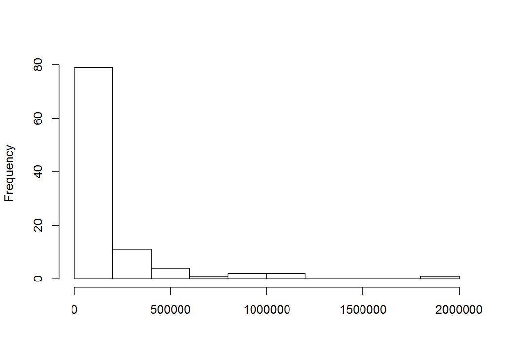

```r
    hist(as.numeric(wfreq[1:100,2]), xlab = '', main = '')
```

### Plot a cloud with the most frequent terms from blogs

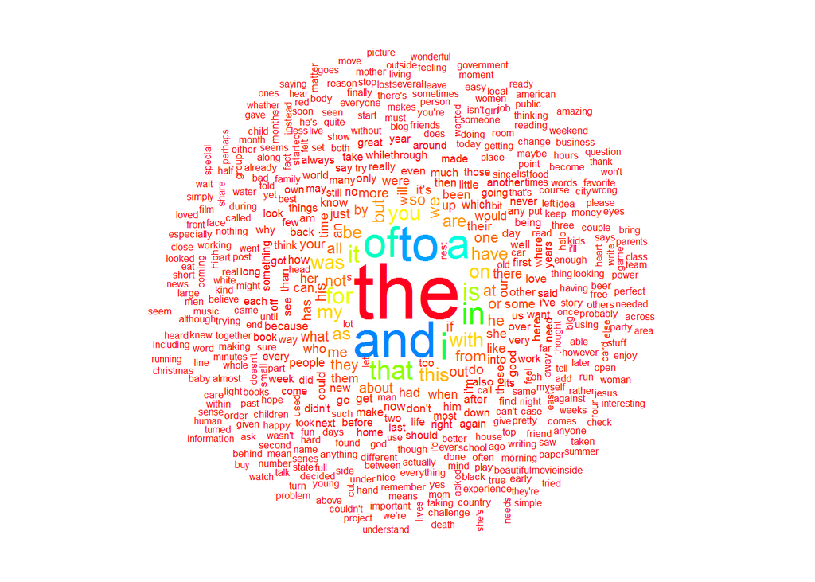

```r
    freq <- colSums(dfm_blogs)
    freq <- sort(freq, decreasing=TRUE)
    words <- names(freq)

    wordcloud(words[1:500], freq[1:500], random.order = F, colors = rainbow(50))
```

```r
    cat('For 1 ngrams we need', count_score(wfreq, .5), 'distinct terms to reach 50% of the total words (ngrams).')
```

```
## For 1 ngrams we need 106 distinct terms to reach 50% of the total words (ngrams).
```

### Word frequecy with 2 ngrams from blogs

```r
    # Get terms frequency from dfm.
    wfreq <- word_freq(dfm_blogs2)
```

### Show the most frequent terms from blogs (2 ngrams)

```r
    head(wfreq,20)
```

```
##          word       freq   rate
## of_the   "of_the"   187136 0.0052
## in_the   "in_the"   154187 0.0043
## to_the   "to_the"   86029  0.0024
## on_the   "on_the"   75266  0.0021
## to_be    "to_be"    68104  0.0019
## and_the  "and_the"  58737  0.0016
## for_the  "for_the"  58128  0.0016
## i_was    "i_was"    49556  0.0014
## and_i    "and_i"    49485  0.0014
## i_have   "i_have"   48074  0.0013
## it_is    "it_is"    47967  0.0013
## it_was   "it_was"   47764  0.0013
## at_the   "at_the"   47419  0.0013
## is_a     "is_a"     45574  0.0013
## in_a     "in_a"     45553  0.0013
## with_the "with_the" 43929  0.0012
## i_am     "i_am"     42470  0.0012
## from_the "from_the" 38110  0.0011
## that_i   "that_i"   37960  0.0011
## of_a     "of_a"     33969  9e-04
```

### Plot a histogram with the most frequent terms from blogs (2 ngrams)

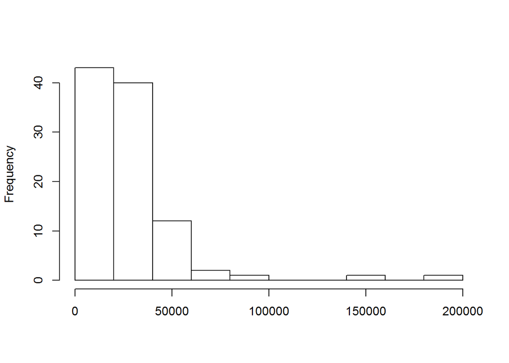

```r
    hist(as.numeric(wfreq[1:100,2]), xlab = '', main = '')
```

### Word frequecy with 3 ngrams from blogs

```r
    # Get terms frequency from dfm.
    wfreq <- word_freq(dfm_blogs3)
```

### Show the most frequent terms from blogs (3 ngrams)

```r
    head(wfreq,20)
```

```
##               word            freq  rate
## one_of_the    "one_of_the"    14441 4e-04
## a_lot_of      "a_lot_of"      12246 3e-04
## as_well_as    "as_well_as"    6899  2e-04
## it_was_a      "it_was_a"      6838  2e-04
## to_be_a       "to_be_a"       6834  2e-04
## some_of_the   "some_of_the"   6713  2e-04
## out_of_the    "out_of_the"    6481  2e-04
## the_end_of    "the_end_of"    6473  2e-04
## be_able_to    "be_able_to"    6232  2e-04
## i_want_to     "i_want_to"     6004  2e-04
## a_couple_of   "a_couple_of"   6001  2e-04
## the_fact_that "the_fact_that" 5426  2e-04
## this_is_a     "this_is_a"     5311  2e-04
## i_have_to     "i_have_to"     5308  2e-04
## the_rest_of   "the_rest_of"   5186  1e-04
## there_is_a    "there_is_a"    5113  1e-04
## i_have_a      "i_have_a"      5094  1e-04
## it_is_a       "it_is_a"       4994  1e-04
## part_of_the   "part_of_the"   4971  1e-04
## i_have_been   "i_have_been"   4961  1e-04
```

### Plot a histogram with the most frequent terms from blogs (3 ngrams)

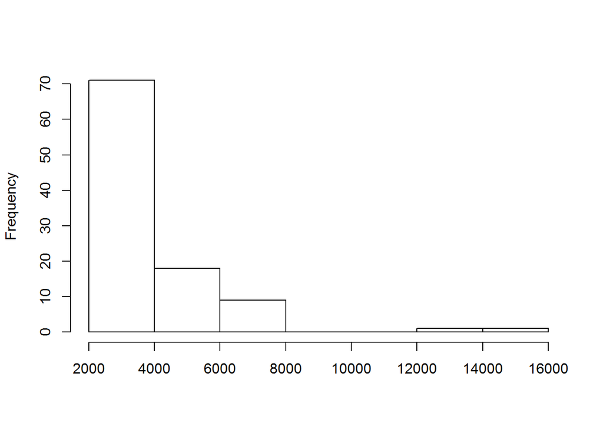

```r
    hist(as.numeric(wfreq[1:100,2]), xlab = '', main = '')
```

### Exploring en_US.news.txt

```r
    # Reading the file
    con_news <- file("final/en_US/en_US.news.txt", "r")
    news <- corpus(readLines(con = con_news, encoding='UTF-8'))
```

### The maximum number of lines in a news

```r
    max(nsentence(news))
```

```
## [1] 28
```

```r
    max(ntoken(news))
```

```
## [1] 1230
```

### Creating the document feature matrix with 1 ngram

```r
    dfm_news <- dfm(news
           , verbose = TRUE
           , toLower = TRUE
           , removeNumbers = TRUE
           , removePunct = TRUE
           , removeSeparators = TRUE
           , removeTwitter = FALSE
           , stem = FALSE
           , ignoredFeatures = NULL
           , keptFeatures = NULL
           , language = ""
           , thesaurus = NULL
           , dictionary = NULL
           , valuetype = c("glob"))
```

```
## Creating a dfm from a corpus ...
##    ... lowercasing
##    ... tokenizing
##    ... indexing documents: 77,259 documents
##    ... indexing features: 92,148 feature types
##    ... created a 77259 x 92148 sparse dfm
##    ... complete.
## Elapsed time: 6.08 seconds.
```

```r
    head(dfm_news)
```

```
## Document-feature matrix of: 77,259 documents, 92,148 features.
## (showing first 6 documents and first 6 features)
##        features
## docs    he wasn't home alone apparently the
##   text1  1      1    1     1          1   0
##   text2  0      0    0     0          0   3
##   text3  0      0    0     0          0   3
##   text4  0      0    0     0          0   5
##   text5  0      0    0     0          0   1
##   text6  0      0    0     0          0   4
```

### Creating the document feature matrix with 2 ngrams

```r
    dfm_news2 <- dfm(news
           , verbose = TRUE
           , toLower = TRUE
           , removeNumbers = TRUE
           , removePunct = TRUE
           , removeSeparators = TRUE
           , removeTwitter = FALSE
           , stem = FALSE
           , ignoredFeatures = NULL
           , keptFeatures = NULL
           , language = ""
           , thesaurus = NULL
           , dictionary = NULL
           , valuetype = c("glob"), ngrams=2)
```

```
## Creating a dfm from a corpus ...
##    ... lowercasing
##    ... tokenizing
##    ... indexing documents: 77,259 documents
##    ... indexing features: 956,567 feature types
##    ... created a 77259 x 956567 sparse dfm
##    ... complete.
## Elapsed time: 16.48 seconds.
```

```r
    head(dfm_news2)
```

```
## Document-feature matrix of: 77,259 documents, 956,567 features.
## (showing first 6 documents and first 6 features)
##        features
## docs    he_wasn't wasn't_home home_alone alone_apparently the_st st_louis
##   text1         1           1          1                1      0        0
##   text2         0           0          0                0      1        1
##   text3         0           0          0                0      0        0
##   text4         0           0          0                0      0        0
##   text5         0           0          0                0      0        0
##   text6         0           0          0                0      0        0
```

### Creating the document feature matrix with 3 ngrams

```r
    dfm_news3 <- dfm(news
           , verbose = TRUE
           , toLower = TRUE
           , removeNumbers = TRUE
           , removePunct = TRUE
           , removeSeparators = TRUE
           , removeTwitter = FALSE
           , stem = FALSE
           , ignoredFeatures = NULL
           , keptFeatures = NULL
           , language = ""
           , thesaurus = NULL
           , dictionary = NULL
           , valuetype = c("glob"), ngrams=3)
```

```
## Creating a dfm from a corpus ...
##    ... lowercasing
##    ... tokenizing
##    ... indexing documents: 77,259 documents
##    ... indexing features: 1,895,878 feature types
##    ... created a 77259 x 1895878 sparse dfm
##    ... complete.
## Elapsed time: 18.69 seconds.
```

```r
    head(dfm_news3)
```

```
## Document-feature matrix of: 77,259 documents, 1,895,878 features.
## (showing first 6 documents and first 6 features)
##        features
## docs    he_wasn't_home wasn't_home_alone home_alone_apparently
##   text1              1                 1                     1
##   text2              0                 0                     0
##   text3              0                 0                     0
##   text4              0                 0                     0
##   text5              0                 0                     0
##   text6              0                 0                     0
##        features
## docs    the_st_louis st_louis_plant louis_plant_had
##   text1            0              0               0
##   text2            1              1               1
##   text3            0              0               0
##   text4            0              0               0
##   text5            0              0               0
##   text6            0              0               0
```

### Word frequecy with 1 ngrams from news

```r
    # Get terms frequency from dfm.
    wfreq <- word_freq(dfm_news)
```

### Show the most frequent terms from news

```r
    head(wfreq,20)
```

```
##      word   freq   rate
## the  "the"  151488 0.0588
## to   "to"   69327  0.0269
## and  "and"  68255  0.0265
## a    "a"    67147  0.0261
## of   "of"   59040  0.0229
## in   "in"   51452  0.02
## for  "for"  26970  0.0105
## that "that" 26379  0.0102
## is   "is"   21959  0.0085
## on   "on"   20563  0.008
## with "with" 19752  0.0077
## said "said" 19170  0.0074
## was  "was"  17624  0.0068
## he   "he"   17584  0.0068
## it   "it"   16735  0.0065
## at   "at"   16480  0.0064
## as   "as"   14615  0.0057
## his  "his"  12109  0.0047
## i    "i"    11907  0.0046
## but  "but"  11647  0.0045
```

### Plot a histogram with the most frequent terms from news

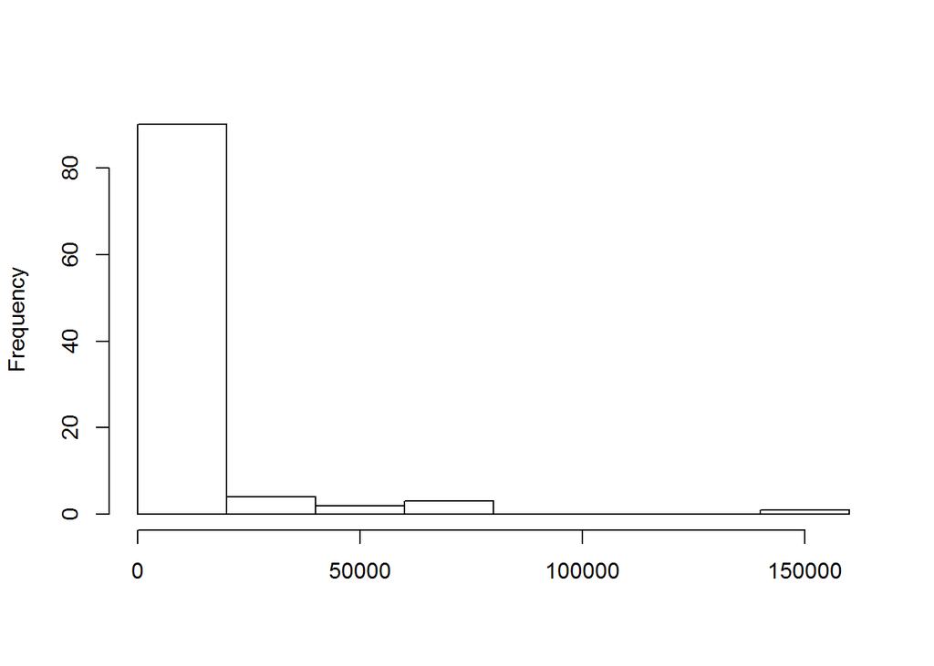

```r
    hist(as.numeric(wfreq[1:100,2]), xlab = '', main = '')
```

### Plot a cloud with the most frequent terms from news

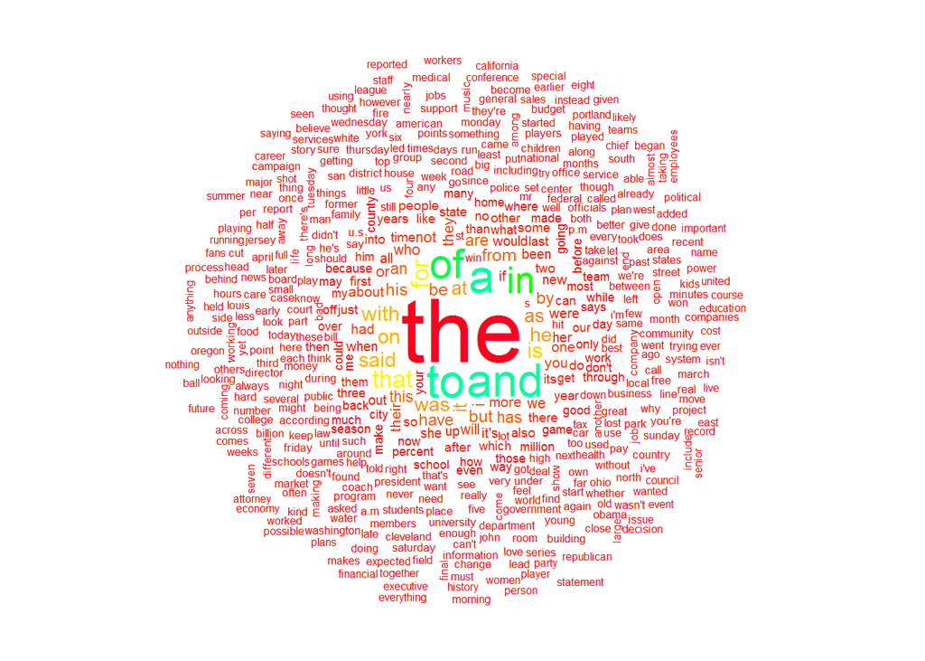

```r
    freq <- colSums(dfm_news)
    freq <- sort(freq, decreasing=TRUE)
    words <- names(freq)

    wordcloud(words[1:500], freq[1:500], random.order = F, colors = rainbow(50))
```

```r
    cat('For 1 ngrams we need', count_score(wfreq, .5), 'distinct terms to reach 50% of the total words (ngrams).')
```

```
## For 1 ngrams we need 195 distinct terms to reach 50% of the total words (ngrams).
```

### Word frequecy with 2 ngrams from news

```r
    # Get terms frequency from dfm.
    wfreq <- word_freq(dfm_news2)
```

### Show the most frequent terms from news (2 ngrams)

```r
    head(wfreq,20)
```

```
##          word       freq  rate
## of_the   "of_the"   14096 0.0056
## in_the   "in_the"   13708 0.0055
## to_the   "to_the"   6442  0.0026
## on_the   "on_the"   5537  0.0022
## for_the  "for_the"  5397  0.0022
## at_the   "at_the"   4516  0.0018
## and_the  "and_the"  4050  0.0016
## in_a     "in_a"     4041  0.0016
## to_be    "to_be"    3552  0.0014
## with_the "with_the" 3323  0.0013
## from_the "from_the" 2804  0.0011
## with_a   "with_a"   2626  0.0011
## of_a     "of_a"     2574  0.001
## he_said  "he_said"  2555  0.001
## as_a     "as_a"     2480  0.001
## for_a    "for_a"    2333  9e-04
## by_the   "by_the"   2184  9e-04
## is_a     "is_a"     2174  9e-04
## it_was   "it_was"   2170  9e-04
## will_be  "will_be"  2151  9e-04
```

### Plot a histogram with the most frequent terms from news (2 ngrams)

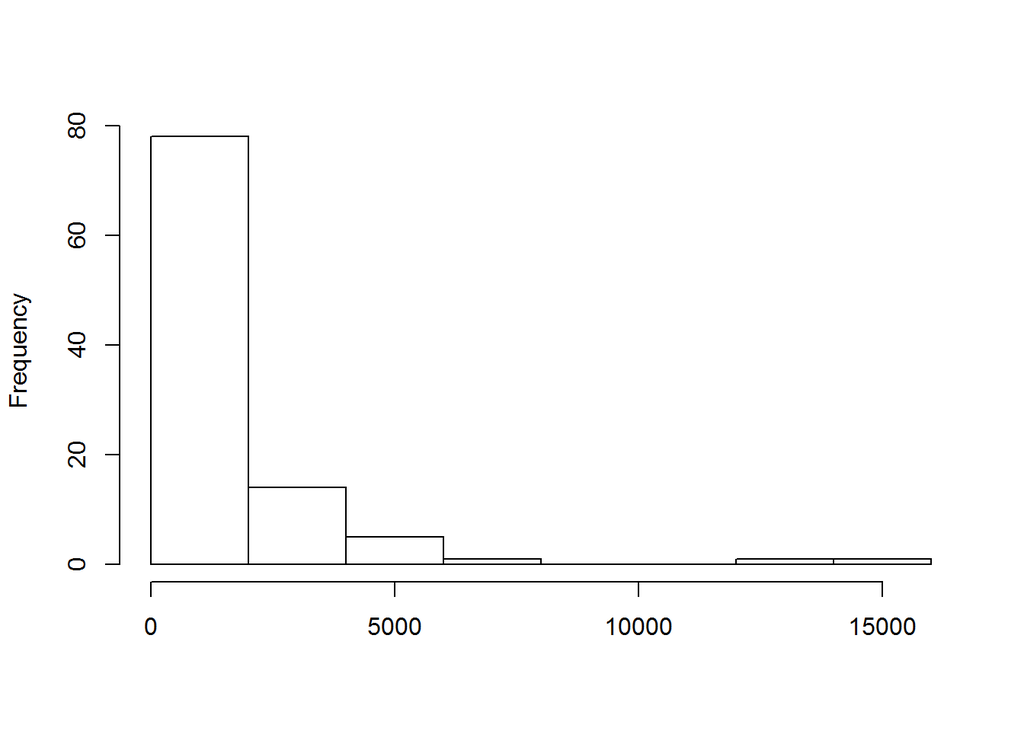

```r
    hist(as.numeric(wfreq[1:100,2]), xlab = '', main = '')
```

### Word frequecy with 3 ngrams from news

```r
    # Get terms frequency from dfm.
    wfreq <- word_freq(dfm_news3)
```

### Show the most frequent terms from news (3 ngrams)

```r
    head(wfreq,20)
```

```
##                   word                freq rate
## one_of_the        "one_of_the"        1080 4e-04
## a_lot_of          "a_lot_of"          876  4e-04
## as_well_as        "as_well_as"        479  2e-04
## according_to_the  "according_to_the"  435  2e-04
## in_the_first      "in_the_first"      425  2e-04
## going_to_be       "going_to_be"       420  2e-04
## part_of_the       "part_of_the"       410  2e-04
## the_end_of        "the_end_of"        407  2e-04
## out_of_the        "out_of_the"        393  2e-04
## some_of_the       "some_of_the"       392  2e-04
## to_be_a           "to_be_a"           382  2e-04
## the_united_states "the_united_states" 345  1e-04
## the_first_time    "the_first_time"    339  1e-04
## it_was_a          "it_was_a"          332  1e-04
## be_able_to        "be_able_to"        320  1e-04
## for_the_first     "for_the_first"     295  1e-04
## said_in_a         "said_in_a"         292  1e-04
## of_the_year       "of_the_year"       273  1e-04
## end_of_the        "end_of_the"        250  1e-04
## most_of_the       "most_of_the"       239  1e-04
```

### Plot a histogram with the most frequent terms from news (3 ngrams)

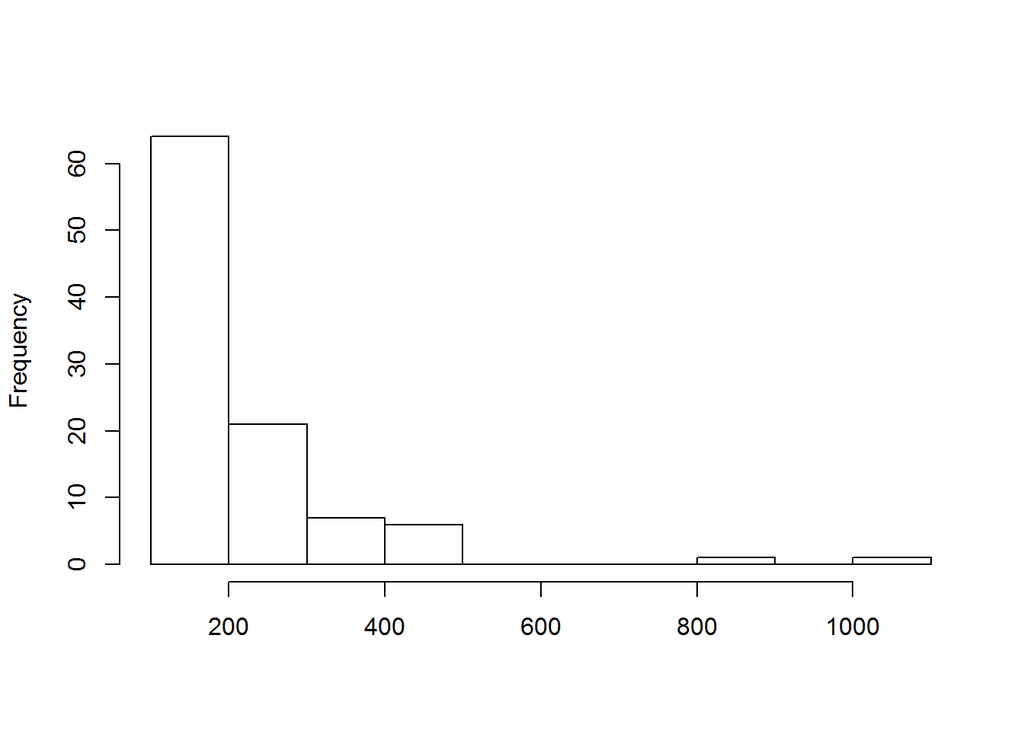

```r
    hist(as.numeric(wfreq[1:100,2]), xlab = '', main = '')
```

### Exploring en_US.twitter.txt

#### Obs.: Due to hardware limitations we are going to read just 1500000 lines from en_US.twitter.txt

```r
    # Reading the file
    con_twitter <- file("final/en_US/en_US.twitter.txt", "rb")
    twitter <- corpus(readLines(con = con_twitter, encoding='UTF-8',1500000))
```

### The maximum number of lines in a twitter

```r
    max(nsentence(twitter))
```

```
## [1] 15
```

```r
    max(ntoken(twitter))
```

```
## [1] 59
```

### Creating the document feature matrix with 1 ngram

```r
    dfm_twitter <- dfm(twitter
           , verbose = TRUE
           , toLower = TRUE
           , removeNumbers = TRUE
           , removePunct = TRUE
           , removeSeparators = TRUE
           , removeTwitter = FALSE
           , stem = FALSE
           , ignoredFeatures = NULL
           , keptFeatures = NULL
           , language = ""
           , thesaurus = NULL
           , dictionary = NULL
           , valuetype = c("glob"))
```

```
## Creating a dfm from a corpus ...
##    ... lowercasing
##    ... tokenizing
##    ... indexing documents: 1,500,000 documents
##    ... indexing features: 317,375 feature types
##    ... created a 1500000 x 317375 sparse dfm
##    ... complete.
## Elapsed time: 129.85 seconds.
```

```r
    head(dfm_twitter)
```

```
## Document-feature matrix of: 1,500,000 documents, 317,375 features.
## (showing first 6 documents and first 6 features)
##        features
## docs    how are you btw thanks for
##   text1   1   1   3   1      1   1
##   text2   0   0   1   0      0   1
##   text3   0   0   0   0      0   0
##   text4   0   0   0   0      0   0
##   text5   0   0   0   0      0   0
##   text6   0   0   0   0      0   0
```

### Creating the document feature matrix with 2 ngrams

```r
    dfm_twitter2 <- dfm(twitter
           , verbose = TRUE
           , toLower = TRUE
           , removeNumbers = TRUE
           , removePunct = TRUE
           , removeSeparators = TRUE
           , removeTwitter = FALSE
           , stem = FALSE
           , ignoredFeatures = NULL
           , keptFeatures = NULL
           , language = ""
           , thesaurus = NULL
           , dictionary = NULL
           , valuetype = c("glob"), ngrams=2)
```

```
## Creating a dfm from a corpus ...
##    ... lowercasing
##    ... tokenizing
##    ... indexing documents: 1,500,000 documents
##    ... indexing features: 3,780,699 feature types
##    ... created a 1500000 x 3780699 sparse dfm
##    ... complete.
## Elapsed time: 244.27 seconds.
```

```r
    head(dfm_twitter2)
```

```
## Document-feature matrix of: 1,500,000 documents, 3,780,699 features.
## (showing first 6 documents and first 6 features)
##        features
## docs    how_are are_you you_btw btw_thanks thanks_for for_the
##   text1       1       1       1          1          1       1
##   text2       0       0       0          0          0       0
##   text3       0       0       0          0          0       0
##   text4       0       0       0          0          0       0
##   text5       0       0       0          0          0       0
##   text6       0       0       0          0          0       0
```

### Creating the document feature matrix with 3 ngrams

```r
    dfm_twitter3 <- dfm(twitter
           , verbose = TRUE
           , toLower = TRUE
           , removeNumbers = TRUE
           , removePunct = TRUE
           , removeSeparators = TRUE
           , removeTwitter = FALSE
           , stem = FALSE
           , ignoredFeatures = NULL
           , keptFeatures = NULL
           , language = ""
           , thesaurus = NULL
           , dictionary = NULL
           , valuetype = c("glob"), ngrams=3)
```

```
## Creating a dfm from a corpus ...
##    ... lowercasing
##    ... tokenizing
##    ... indexing documents: 1,500,000 documents
##    ... indexing features: 9,207,043 feature types
##    ... created a 1500000 x 9207043 sparse dfm
##    ... complete.
## Elapsed time: 293.44 seconds.
```

```r
    head(dfm_twitter3)
```

```
## Document-feature matrix of: 1,500,000 documents, 9,207,043 features.
## (showing first 6 documents and first 6 features)
##        features
## docs    how_are_you are_you_btw you_btw_thanks btw_thanks_for
##   text1           1           1              1              1
##   text2           0           0              0              0
##   text3           0           0              0              0
##   text4           0           0              0              0
##   text5           0           0              0              0
##   text6           0           0              0              0
##        features
## docs    thanks_for_the for_the_rt
##   text1              1          1
##   text2              0          0
##   text3              0          0
##   text4              0          0
##   text5              0          0
##   text6              0          0
```

### Word frequecy with 1 ngrams from twitter

```r
    # Get terms frequency from dfm.
    wfreq <- word_freq(dfm_twitter)
```

### Show the most frequent terms from twitter

```r
    head(wfreq,20)
```

```
##      word   freq   rate
## the  "the"  595841 0.0317
## to   "to"   500950 0.0267
## i    "i"    459230 0.0244
## a    "a"    387451 0.0206
## you  "you"  348762 0.0186
## and  "and"  278632 0.0148
## for  "for"  244730 0.013
## in   "in"   239747 0.0128
## of   "of"   227975 0.0121
## is   "is"   227951 0.0121
## it   "it"   187644 0.01
## my   "my"   185436 0.0099
## on   "on"   175667 0.0094
## that "that" 148995 0.0079
## me   "me"   128958 0.0069
## be   "be"   119273 0.0063
## at   "at"   118554 0.0063
## with "with" 110007 0.0059
## your "your" 108528 0.0058
## have "have" 107010 0.0057
```

### Plot a histogram with the most frequent terms from twitter

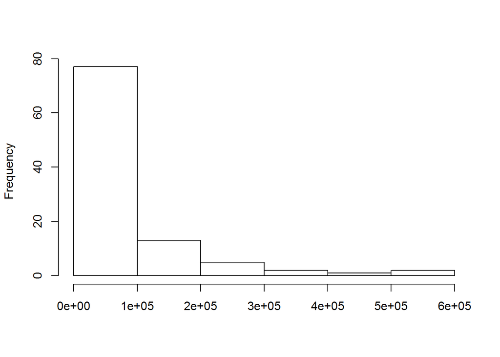

```r
    hist(as.numeric(wfreq[1:100,2]), xlab = '', main = '')
```

### Plot a cloud with the most frequent terms from twitter

[figure not shown]

```r
    freq <- colSums(dfm_twitter)
    freq <- sort(freq, decreasing=TRUE)
    words <- names(freq)

    wordcloud(words[1:500], freq[1:500], random.order = F, colors = rainbow(50))
```

```r
    cat('For 1 ngrams we need', count_score(wfreq, .5), 'distinct terms to reach 50% of the total words (ngrams).')
```

```
## For 1 ngrams we need 124 distinct terms to reach 50% of the total words (ngrams).
```

### Word frequecy with 2 ngrams from twitter

```r
    # Get terms frequency from dfm.
    wfreq <- word_freq(dfm_twitter2)
```

### Show the most frequent terms from twitter (2 ngrams)

```r
    head(wfreq,20)
```

```
##            word         freq  rate
## in_the     "in_the"     49880 0.0029
## for_the    "for_the"    47162 0.0027
## of_the     "of_the"     36011 0.0021
## on_the     "on_the"     30640 0.0018
## to_be      "to_be"      30030 0.0017
## to_the     "to_the"     27655 0.0016
## thanks_for "thanks_for" 27402 0.0016
## at_the     "at_the"     23585 0.0014
## i_love     "i_love"     22756 0.0013
## going_to   "going_to"   21730 0.0013
## have_a     "have_a"     21475 0.0012
## thank_you  "thank_you"  21177 0.0012
## if_you     "if_you"     21109 0.0012
## i_have     "i_have"     20122 0.0012
## i_am       "i_am"       18912 0.0011
## for_a      "for_a"      18853 0.0011
## to_see     "to_see"     17177 0.001
## is_a       "is_a"       17086 0.001
## to_get     "to_get"     17059 0.001
## will_be    "will_be"    16255 9e-04
```

### Plot a histogram with the most frequent terms from twitter (2 ngrams)

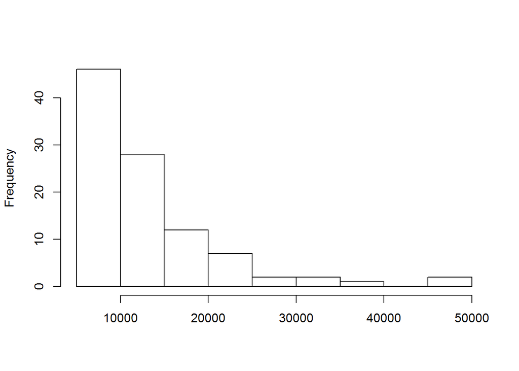

```r
    hist(as.numeric(wfreq[1:100,2]), xlab = '', main = '')
```

### Word frequecy with 3 ngrams from twitter

```r
    # Get terms frequency from dfm.
    wfreq <- word_freq(dfm_twitter3)
```

### Show the most frequent terms from twitter (3 ngrams)

```r
    head(wfreq,20)
```

```
##                    word                 freq  rate
## thanks_for_the     "thanks_for_the"     15055 0.001
## looking_forward_to "looking_forward_to" 5635  4e-04
## thank_you_for      "thank_you_for"      5533  4e-04
## i_love_you         "i_love_you"         5279  3e-04
## for_the_follow     "for_the_follow"     5008  3e-04
## going_to_be        "going_to_be"        4736  3e-04
## can't_wait_to      "can't_wait_to"      4650  3e-04
## i_want_to          "i_want_to"          4575  3e-04
## a_lot_of           "a_lot_of"           3904  2e-04
## to_be_a            "to_be_a"            3885  2e-04
## i_need_to          "i_need_to"          3764  2e-04
## i_have_a           "i_have_a"           3701  2e-04
## one_of_the         "one_of_the"         3553  2e-04
## have_a_great       "have_a_great"       3436  2e-04
## to_see_you         "to_see_you"         3373  2e-04
## i_have_to          "i_have_to"          3189  2e-04
## i'm_going_to       "i'm_going_to"       3014  2e-04
## is_going_to        "is_going_to"        2965  2e-04
## you_have_a         "you_have_a"         2796  2e-04
## for_the_rt         "for_the_rt"         2795  2e-04
```

### Plot a histogram with the most frequent terms from twitter (3 ngrams)

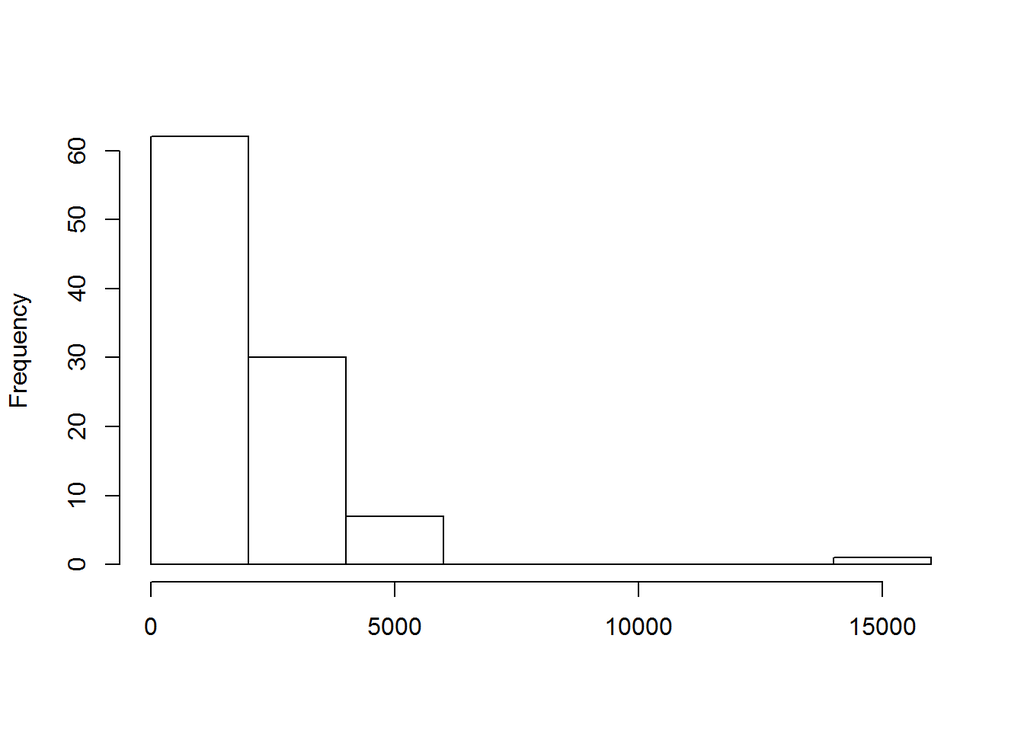

```r
    hist(as.numeric(wfreq[1:100,2]), xlab = '', main = '')
```